# BTR Results Overview

2024-07-08 10:20:01.984882

# Emissions

## Energy CO2 Emissions

### Sector

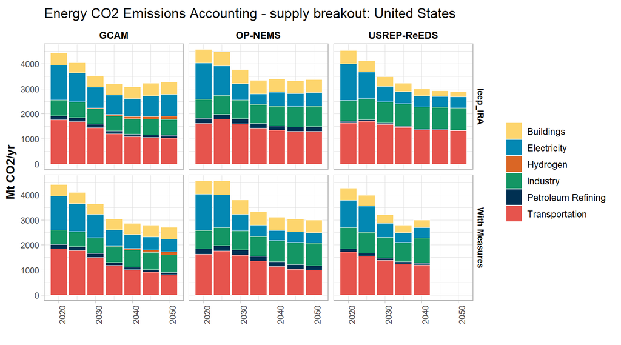

In the “With Measures” scenarios, Energy CO<sub>2</sub> emissions reductions range by model from 2020 to 2040:

### Model

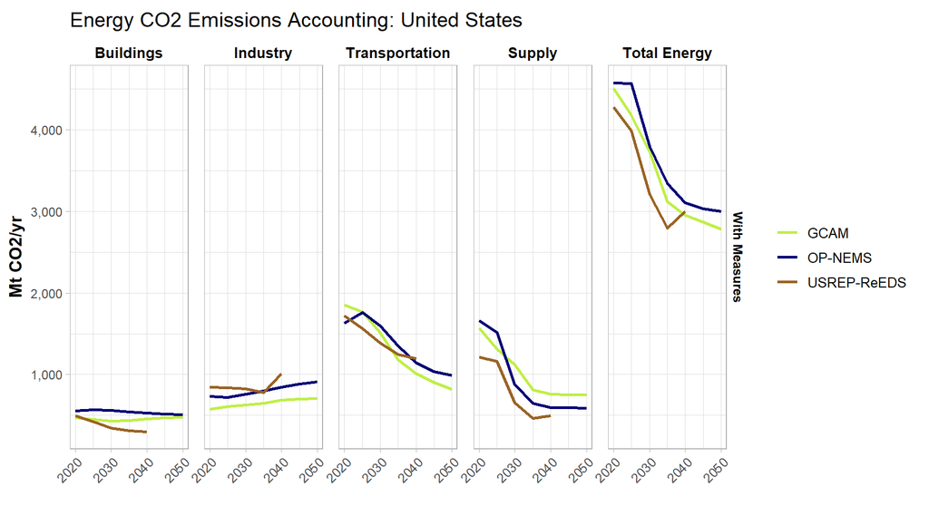

# Energy Consumption

## Final Energy

### Fuel

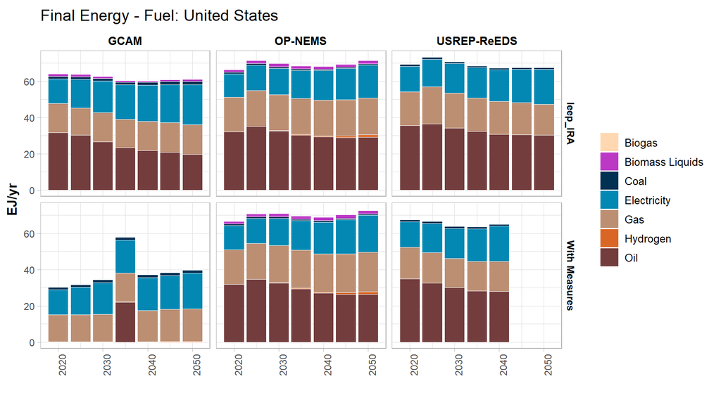

### Fuel by Model

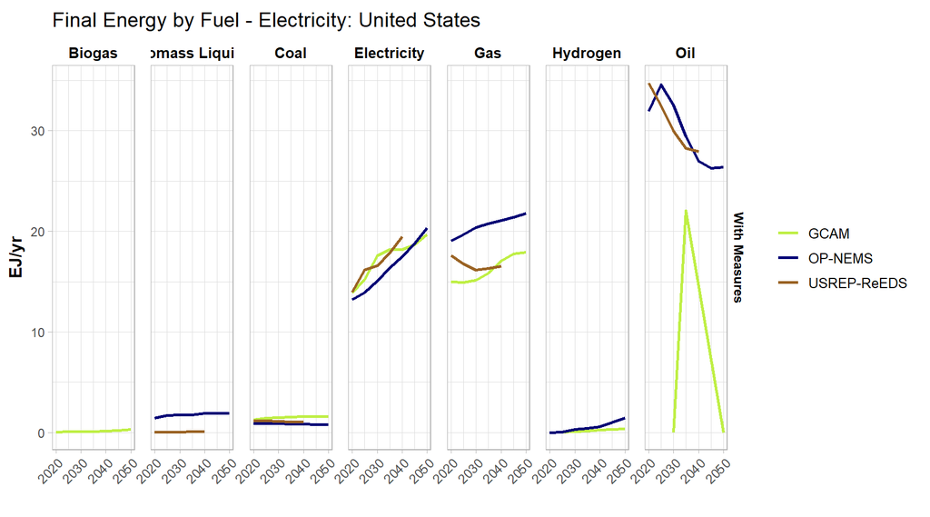

### Fuel by Model - Zoom

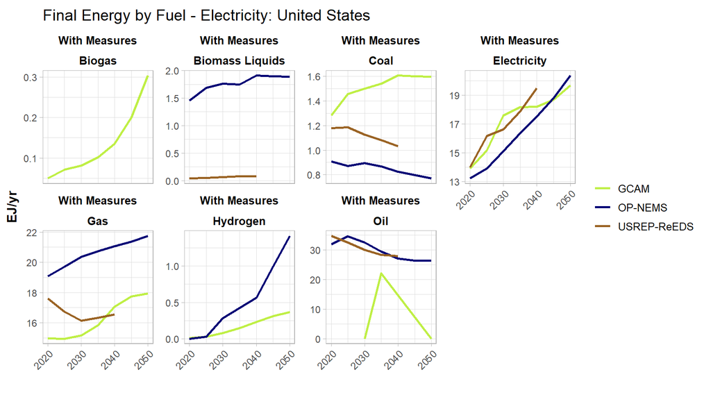

Energy consumption is estimated to change from 2020 to 2040:

- GCAM: 23%
- OP-NEMS: 3%
- USREP-ReEDS: -4%

By fuel-type, energy consumption is estimated to change from 2020 to 2040:

- Coal:
  - GCAM: 25%
  - OP-NEMS: -9%
  - USREP-ReEDS: -12%
- Electricity:
  - GCAM: 31%
  - OP-NEMS: 32%
  - USREP-ReEDS: 39%
- Gas:
  - GCAM: 14%
  - OP-NEMS: 10%
  - USREP-ReEDS: -6%
- Oil:
  - GCAM: NA%
  - OP-NEMS: -15%
  - USREP-ReEDS: -20%

### Sector

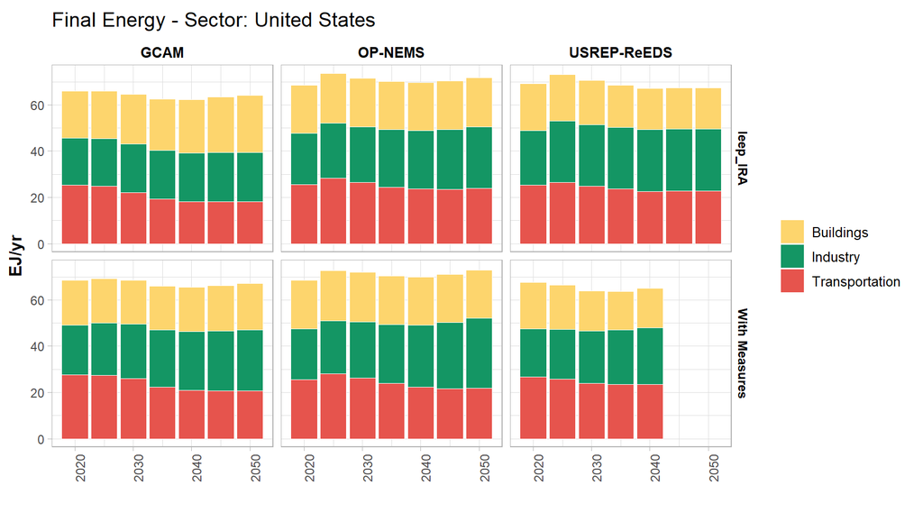

By sector, energy consumption is estimated to change from 2020 to 2040:

- Buildings:
  - GCAM: -2%
  - OP-NEMS: -1%
  - USREP-ReEDS: -15%
- Industry:
  - GCAM: 20%
  - OP-NEMS: 22%
  - USREP-ReEDS: 18%
- Transportation:
  - GCAM: -25%
  - OP-NEMS: -13%
  - USREP-ReEDS: -12%

### Sector by Model

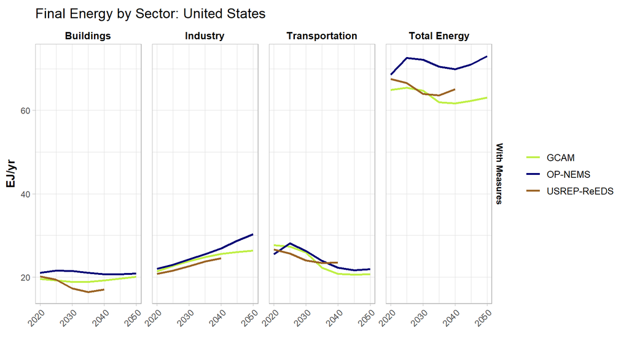

## Final Energy by Sector

### Buildings

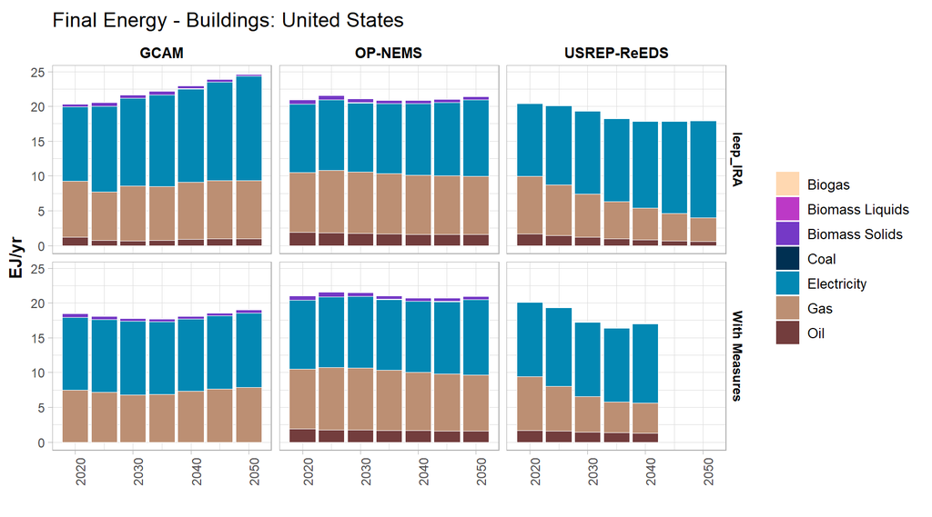

### Buildings by Model

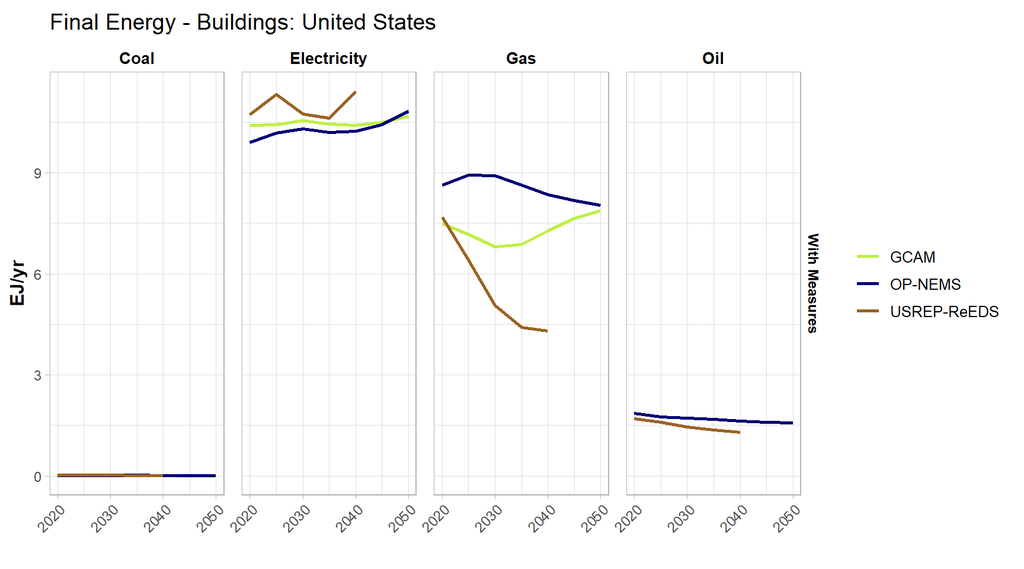

### Industry

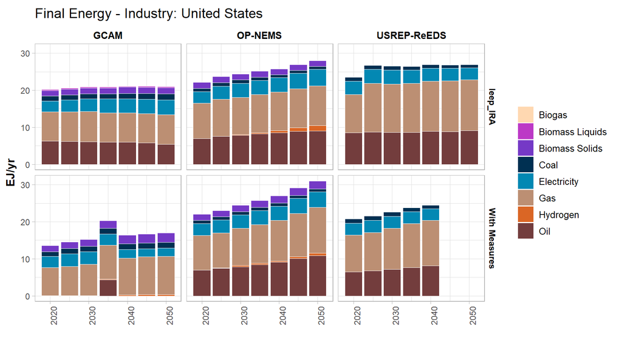

### Industry by Model

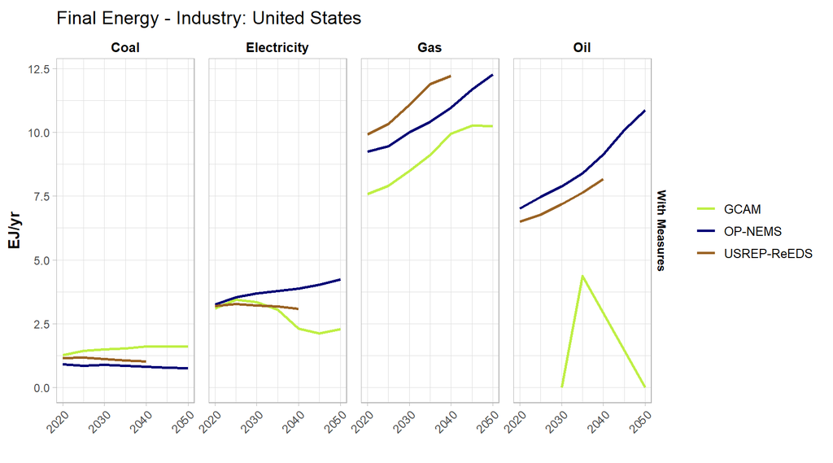

### Transportation

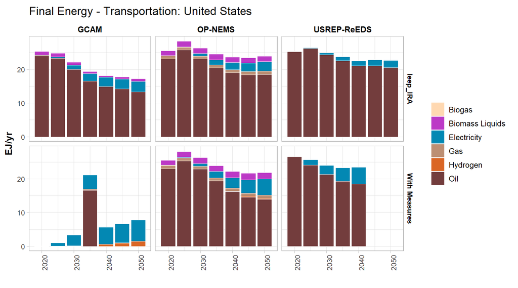

### Transportation by Model

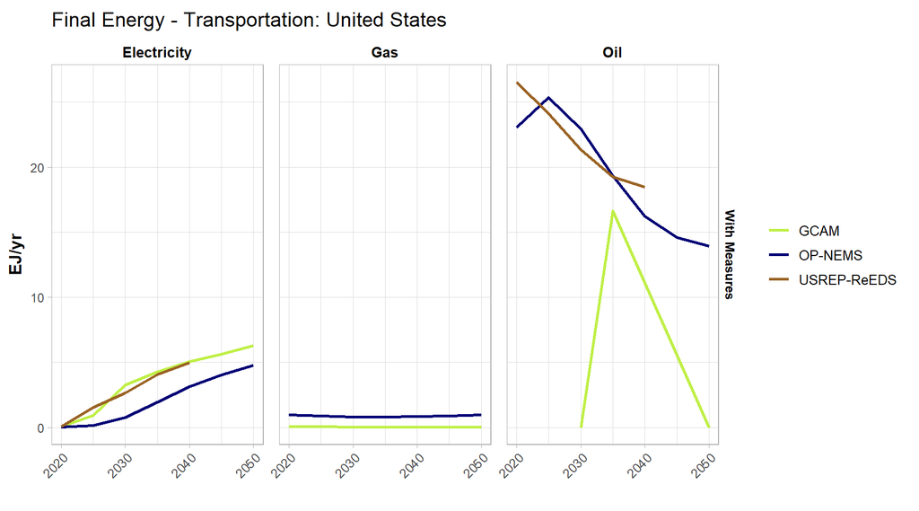

## Percent Electricity

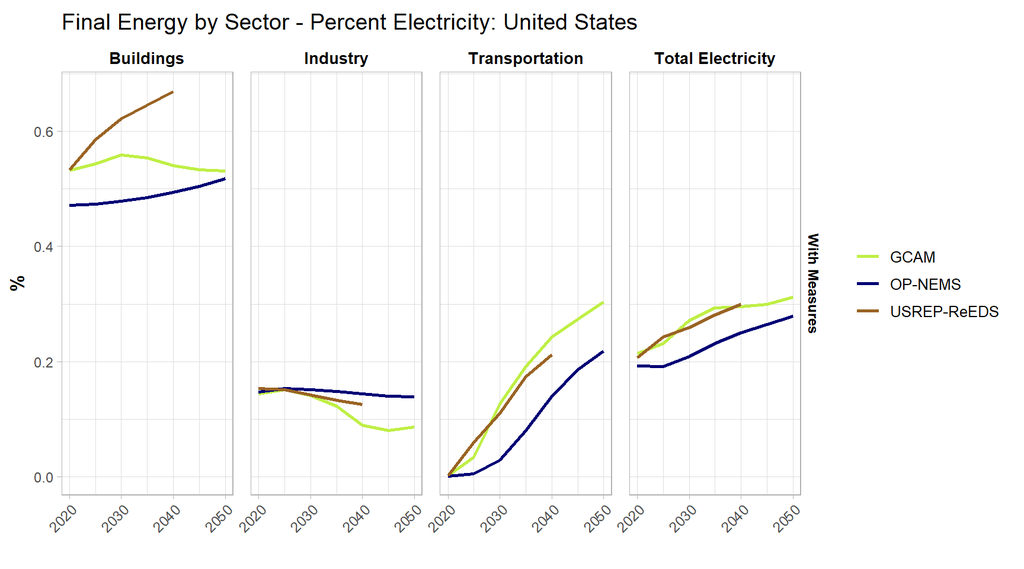

# Energy Production

## Secondary Energy

### Fuel

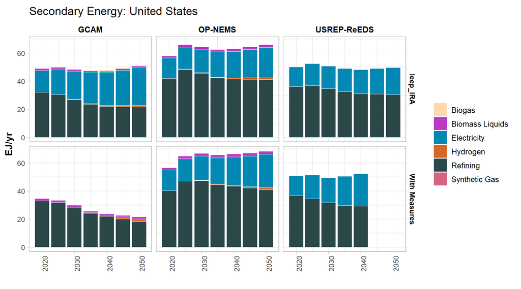

### Model

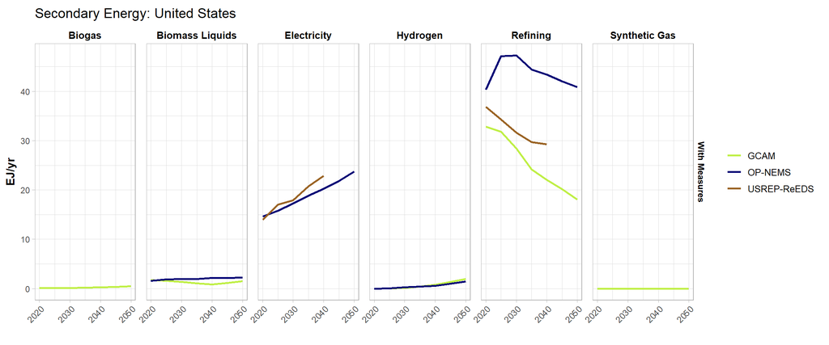

### Model - Zoom

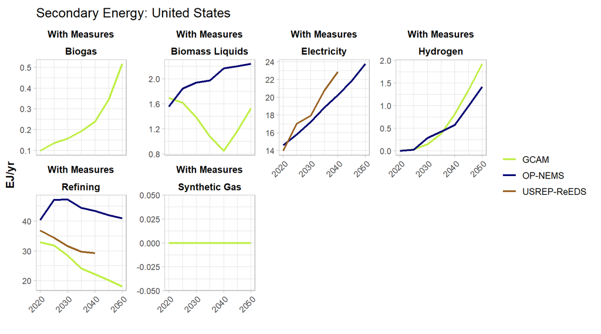

## Electricity Production

### Generation

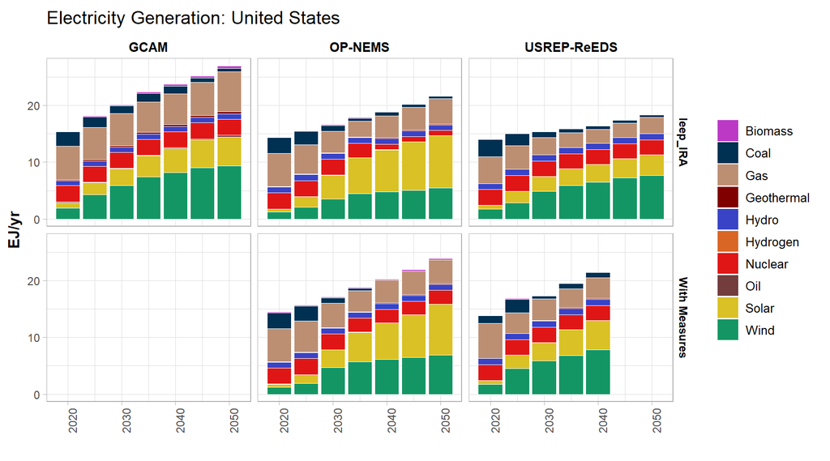

### Generation by Model

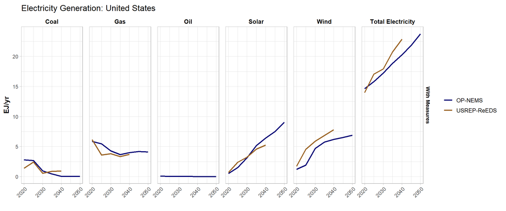

### Generation by Model - Zoom

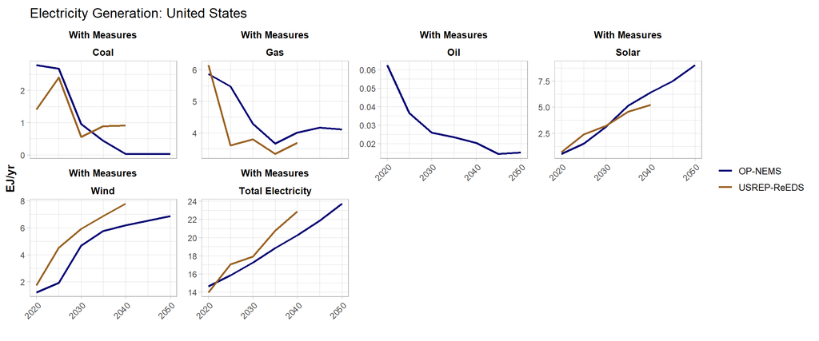

### Capacity

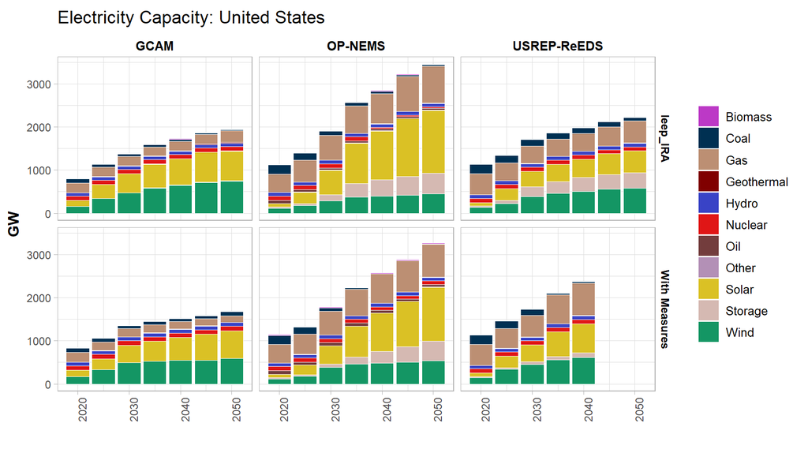

Electricity capacity is estimated to increase from 2020 to 2040:

- GCAM: 82%
- OP-NEMS: 126%
- USREP-ReEDS: 109%

By technology, electricity capacity is estimated to change from 2020 to 2040:

- Coal:
  - GCAM: -35%
  - OP-NEMS: -97%
  - USREP-ReEDS: -83%
- Gas:
  - GCAM: -22%
  - OP-NEMS: 58%
  - USREP-ReEDS: 54%
- Oil:
  - GCAM: 325%
  - OP-NEMS: -24%
- Solar:
  - GCAM: 260%
  - OP-NEMS: 981%
  - USREP-ReEDS: 708%
- Storage:
  - OP-NEMS: 1015%
  - USREP-ReEDS: 349%
- Wind:
  - GCAM: 223%
  - OP-NEMS: 311%
  - USREP-ReEDS: 327%

### Capacity by Model

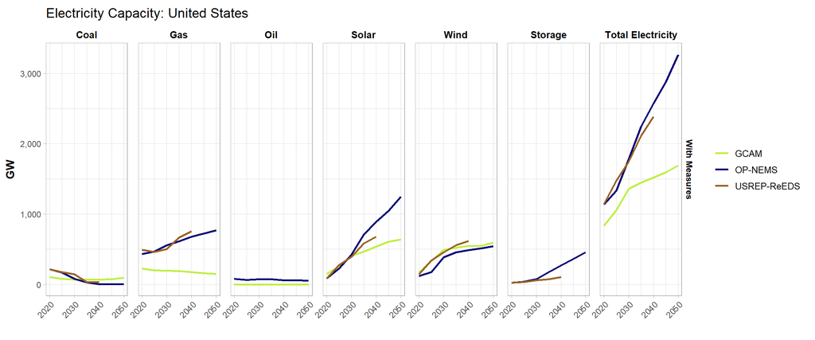

### Capacity by Model - Zoom

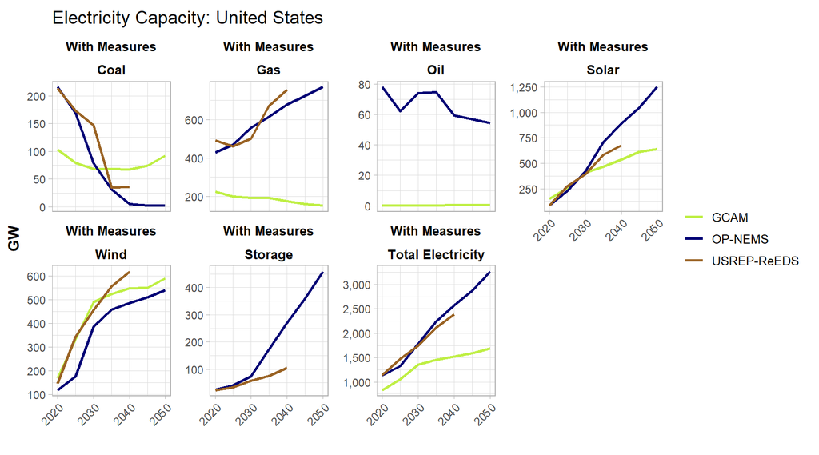

## Electricity Production - Combustion

### Generation

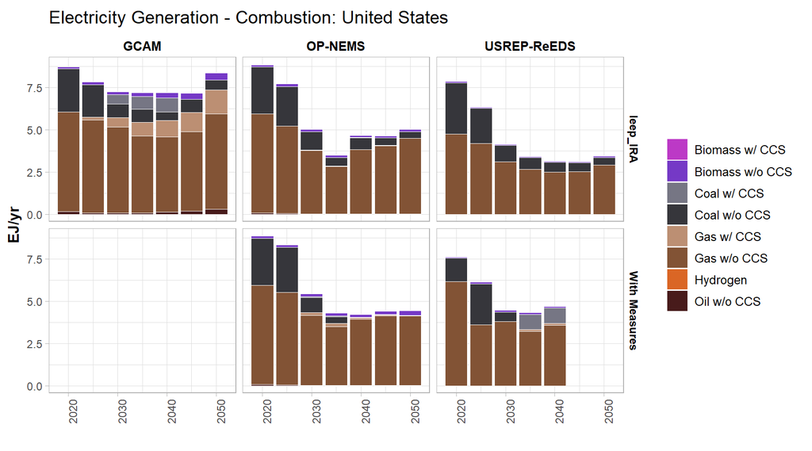

### Generation by Model

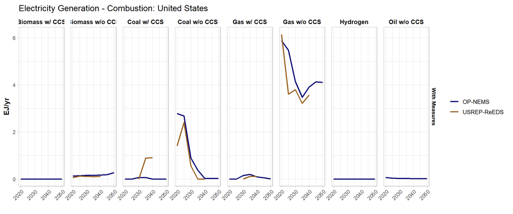

### Generation by Model - Zoom

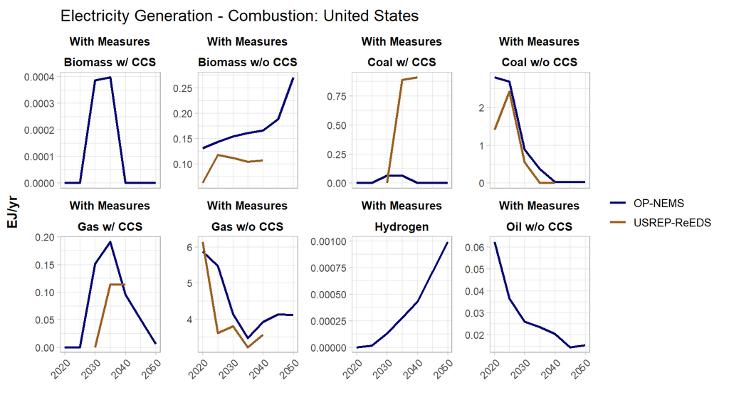

### Capacity

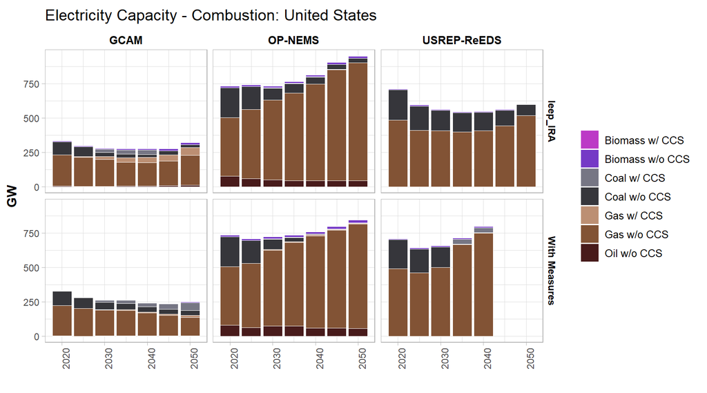

### Capacity by Model

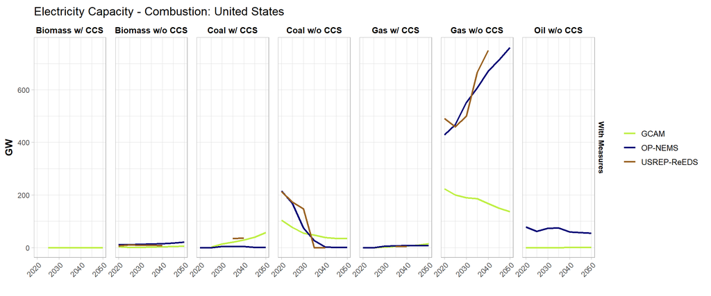

### Capacity by Model - Zoom

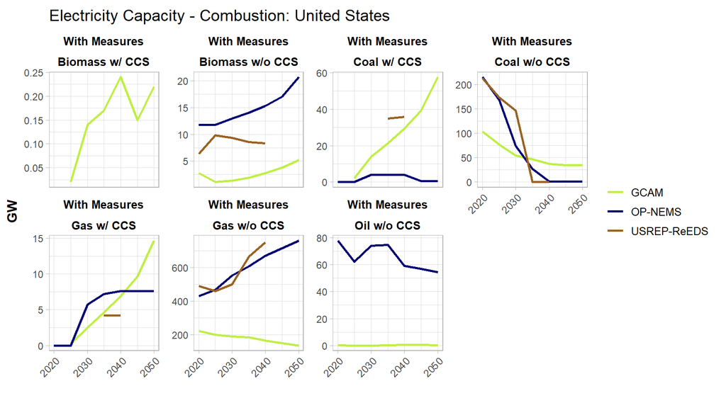

## Electricity Production - Non-Combustion

### Generation

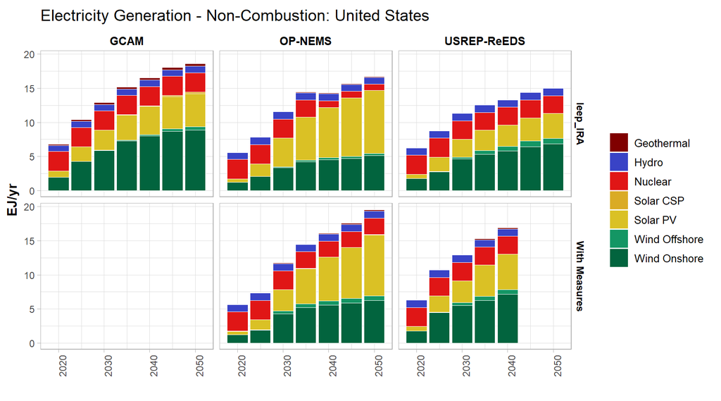

### Generation by Model

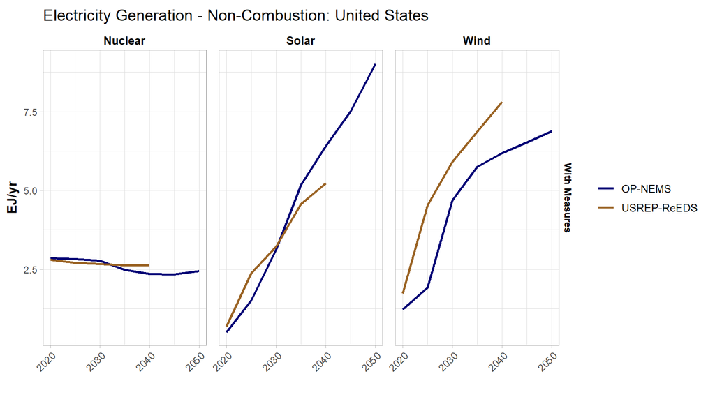

### Capacity

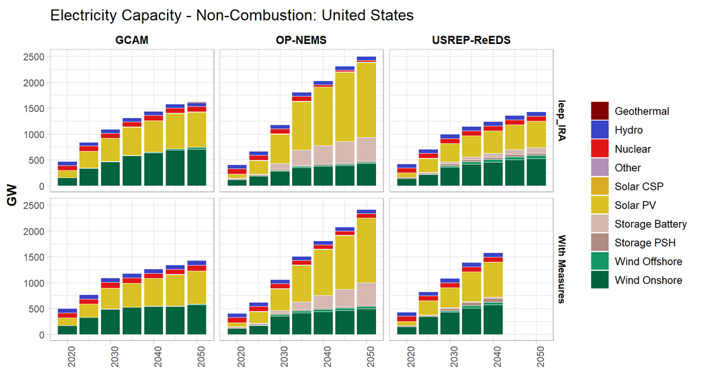